# Question 1

### Part 1

In this part, data is read into a data frame and some functions are called using this data frame:

1. head: returns 5 first rows read (5 is a default number) in data frame type.
2. tail: returns 5 last rows read (5 default number) in data frame type
3. describe: returns some attributes such as mean and count of each column in data frame data type
4. info: prints information about a data frame including the index dtype and column dtypes, non-null values and memory usage

```python
import pandas as pd
import matplotlib.pyplot as plt
import numpy as np

data = pd.read_csv('AdmissionPredict.csv', delimiter = ',')
data
```

|  | Serial No. | GRE Score | TOEFL Score | University Rating | SOP | LOR | CGPA | Research | Chance of Admit |
| --- | --- | --- | --- | --- | --- | --- | --- | --- | --- |
| 0 | 1 | 337.0 | 118.0 | 4 | 4.5 | 4.5 | 9.65 | 1 | 0.92 |
| 1 | 2 | 324.0 | 107.0 | 4 | 4.0 | 4.5 | 8.87 | 1 | NaN |
| 2 | 3 | 316.0 | NaN | 3 | 3.0 | 3.5 | 8.00 | 1 | 0.72 |
| 3 | 4 | NaN | 110.0 | 3 | 3.5 | 2.5 | 8.67 | 1 | 0.80 |
| 4 | 5 | 314.0 | 103.0 | 2 | 2.0 | 3.0 | 8.21 | 0 | 0.65 |
| ... | ... | ... | ... | ... | ... | ... | ... | ... | ... |
| 395 | 396 | 324.0 | 110.0 | 3 | 3.5 | 3.5 | 9.04 | 1 | 0.82 |
| 396 | 397 | 325.0 | 107.0 | 3 | 3.0 | 3.5 | 9.11 | 1 | NaN |
| 397 | 398 | 330.0 | 116.0 | 4 | 5.0 | 4.5 | 9.45 | 1 | 0.91 |
| 398 | 399 | 312.0 | 103.0 | 3 | 3.5 | 4.0 | 8.78 | 0 | 0.67 |
| 399 | 400 | 333.0 | 117.0 | 4 | 5.0 | 4.0 | 9.66 | 1 | 0.95 |

400 rows × 9 columns

```python
data.head()
```

|  | Serial No. | GRE Score | TOEFL Score | University Rating | SOP | LOR | CGPA | Research | Chance of Admit |
| --- | --- | --- | --- | --- | --- | --- | --- | --- | --- |
| 0 | 1 | 337.0 | 118.0 | 4 | 4.5 | 4.5 | 9.65 | 1 | 0.92 |
| 1 | 2 | 324.0 | 107.0 | 4 | 4.0 | 4.5 | 8.87 | 1 | NaN |
| 2 | 3 | 316.0 | NaN | 3 | 3.0 | 3.5 | 8.00 | 1 | 0.72 |
| 3 | 4 | NaN | 110.0 | 3 | 3.5 | 2.5 | 8.67 | 1 | 0.80 |
| 4 | 5 | 314.0 | 103.0 | 2 | 2.0 | 3.0 | 8.21 | 0 | 0.65 |

```python
data.tail()
```

|  | Serial No. | GRE Score | TOEFL Score | University Rating | SOP | LOR | CGPA | Research | Chance of Admit |
| --- | --- | --- | --- | --- | --- | --- | --- | --- | --- |
| 395 | 396 | 324.0 | 110.0 | 3 | 3.5 | 3.5 | 9.04 | 1 | 0.82 |
| 396 | 397 | 325.0 | 107.0 | 3 | 3.0 | 3.5 | 9.11 | 1 | NaN |
| 397 | 398 | 330.0 | 116.0 | 4 | 5.0 | 4.5 | 9.45 | 1 | 0.91 |
| 398 | 399 | 312.0 | 103.0 | 3 | 3.5 | 4.0 | 8.78 | 0 | 0.67 |
| 399 | 400 | 333.0 | 117.0 | 4 | 5.0 | 4.0 | 9.66 | 1 | 0.95 |

```python
data.describe()
```

|  | Serial No. | GRE Score | TOEFL Score | University Rating | SOP | LOR | CGPA | Research | Chance of Admit |
| --- | --- | --- | --- | --- | --- | --- | --- | --- | --- |
| count | 400.000000 | 378.000000 | 380.000000 | 400.000000 | 400.000000 | 400.000000 | 380.000000 | 400.000000 | 384.000000 |
| mean | 200.500000 | 316.759259 | 107.386842 | 3.087500 | 3.400000 | 3.452500 | 8.604737 | 0.547500 | 0.724375 |
| std | 115.614301 | 11.415599 | 6.048645 | 1.143728 | 1.006869 | 0.898478 | 0.599167 | 0.498362 | 0.142964 |
| min | 1.000000 | 290.000000 | 92.000000 | 1.000000 | 1.000000 | 1.000000 | 6.800000 | 0.000000 | 0.340000 |
| 25% | 100.750000 | 308.250000 | 103.000000 | 2.000000 | 2.500000 | 3.000000 | 8.170000 | 0.000000 | 0.640000 |
| 50% | 200.500000 | 317.000000 | 107.000000 | 3.000000 | 3.500000 | 3.500000 | 8.640000 | 1.000000 | 0.730000 |
| 75% | 300.250000 | 325.000000 | 112.000000 | 4.000000 | 4.000000 | 4.000000 | 9.080000 | 1.000000 | 0.830000 |
| max | 400.000000 | 340.000000 | 120.000000 | 5.000000 | 5.000000 | 5.000000 | 9.920000 | 1.000000 | 0.970000 |

```python
data.info()
```

```
<class 'pandas.core.frame.DataFrame'>
RangeIndex: 400 entries, 0 to 399
Data columns (total 9 columns):
 #   Column             Non-Null Count  Dtype
---  ------             --------------  -----
 0   Serial No.         400 non-null    int64
 1   GRE Score          378 non-null    float64
 2   TOEFL Score        380 non-null    float64
 3   University Rating  400 non-null    int64
 4   SOP                400 non-null    float64
 5   LOR                400 non-null    float64
 6   CGPA               380 non-null    float64
 7   Research           400 non-null    int64
 8   Chance of Admit    384 non-null    float64
dtypes: float64(6), int64(3)
memory usage: 28.2 KB
```

### Part 2

To count the number of NaN of each column, count function of pandas library is used which returns the count of non-NA cells for each column or row (the default value of this function is 0 so the number of NaNs of each column is returned) in series type. This series is subtracted by len(data) which is of type int and determines size of each column

```python
len(data) - data.count()
```

```
Serial No.            0
GRE Score            22
TOEFL Score          20
University Rating     0
SOP                   0
LOR                   0
CGPA                 20
Research              0
Chance of Admit      16
dtype: int64
```

### Part 3

Last column is dropped at first to prevent filling NaNs of chance of admit which will be filled in the lats part. To do this drop function is used which takes a label and axis and drops a row or a column. Axis=1 indicates that a column would be dropped.  
After dropping the last column, data frame empty cells should be filled with average value of each column. Each emty cell would be filled because we need all of the information of all rows in the following parts. Using average numbers is a good method in order to estimate the real value of empty cells because it's easy and fast and works well with small numerical datasets. To reach full data frame, fillna method is used which takes Series of values specifying which value to use for each index (for a Series) or column (for a DataFrame). The Series is calculated by mean function which returns the mean of each column.

```python
dataNoLastColumn = data.drop(labels='Chance of Admit', axis=1)
filledData = dataNoLastColumn.fillna(dataNoLastColumn.mean(axis=0))
filledData['Chance of Admit'] = data['Chance of Admit']
type(dataNoLastColumn.mean(axis=0))
# filledData
```

```
pandas.core.series.Series
```

# Question 2

### Part 1

Scatter plots are used to see the actual effect of different properties of each student on his/her chance of admitance.  
To make these plots, matplotlib library is used. Subplot is used to create a figure and a grid of subplots with a single call, while providing reasonable control over how the individual plots are created. To plot each figure, scatter method is invoked which takes a set of X and Y axes.  
For example, in the first plot, dots are distributed in the whole surface so serial number wouldn't be a good measure to predict chance of admittance of a student but in the CGPA plot, dots are forming a line declaring that CGPA would be a better measure.

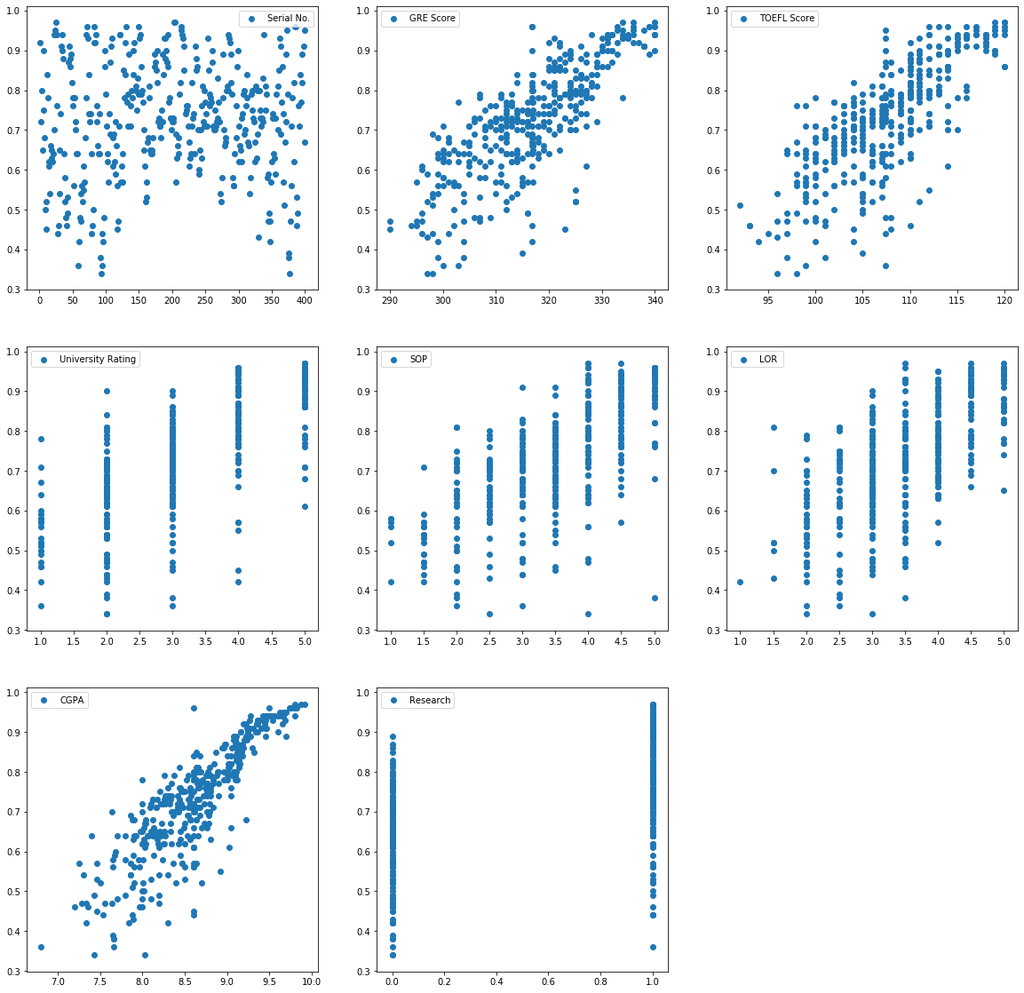

```python
plt.figure(figsize=(20,20))
for i,col in enumerate(filledData.columns):
    if (i == 8):
        break
    plt.subplot(3, 3, i+1)
    plt.scatter(filledData[col], data["Chance of Admit"], label=col)
    plt.legend()
```

### Part 2

Linear correlation is a measure of dependence between two random variables that can take values between -1 and 1. It is proportional to covariance and its interpretation is very similar to that of covariance.  
To find the attribute which has the closer correlation to 1 or -1, corr method is used. As we see in the results, **CGPA** attribute has the closest correlation to 1 and thus is the best attribute which can help us with calculating chance of admittance for students.

```python
filledData.corr()
```

|  | Serial No. | GRE Score | TOEFL Score | University Rating | SOP | LOR | CGPA | Research | Chance of Admit |
| --- | --- | --- | --- | --- | --- | --- | --- | --- | --- |
| Serial No. | 1.000000 | -0.102867 | -0.157648 | -0.169948 | -0.166932 | -0.088221 | -0.062254 | -0.063138 | 0.047057 |
| GRE Score | -0.102867 | 1.000000 | 0.803483 | 0.659972 | 0.599892 | 0.544010 | 0.794507 | 0.572454 | 0.785166 |
| TOEFL Score | -0.157648 | 0.803483 | 1.000000 | 0.681877 | 0.633790 | 0.555354 | 0.799066 | 0.498658 | 0.758534 |
| University Rating | -0.169948 | 0.659972 | 0.681877 | 1.000000 | 0.734523 | 0.660123 | 0.733424 | 0.447783 | 0.707191 |
| SOP | -0.166932 | 0.599892 | 0.633790 | 0.734523 | 1.000000 | 0.729593 | 0.695528 | 0.444029 | 0.680752 |
| LOR | -0.088221 | 0.544010 | 0.555354 | 0.660123 | 0.729593 | 1.000000 | 0.660742 | 0.396859 | 0.663452 |
| CGPA | -0.062254 | 0.794507 | 0.799066 | 0.733424 | 0.695528 | 0.660742 | 1.000000 | 0.514092 | 0.855675 |
| Research | -0.063138 | 0.572454 | 0.498658 | 0.447783 | 0.444029 | 0.396859 | 0.514092 | 1.000000 | 0.548443 |
| Chance of Admit | 0.047057 | 0.785166 | 0.758534 | 0.707191 | 0.680752 | 0.663452 | 0.855675 | 0.548443 | 1.000000 |

# Question 3

### Part 1

To get the number of students with mentioned properties, loc method is used. Loc method takes a boolean array of the same length as the axis being sliced and returns a data frame of students with mentioned properties.  
To make the boolean array, we first calculate (filledData['CGPA'] >= 9) and (filledData['TOEFL Score'] >= 110) which both are boolean arrays and use the bitwise and to make sure that the student has both properties. True values are rows which satisfy bit of the properties mentioned in the question.

```python
len(filledData.loc[(filledData['CGPA'] >= 9) & (filledData['TOEFL Score'] >= 110)])
```

```
97
```

### Part 2

To get the desired output, we should first categorize the data frame by it's university rating attribute. Groupby method is used for this purpose which takes a criteria and splits the data into groups. The we use the mean function to calculate mean of each property of each group and then print the GRE Score column of this data frame.

```python
# filledData.groupby('University Rating').mean().get('GRE Score')
filledData.groupby('University Rating').mean()
```

| University Rating | Serial No. | GRE Score | TOEFL Score | SOP | LOR | CGPA | Research | Chance of Admit |
| --- | --- | --- | --- | --- | --- | --- | --- | --- |
| 1 | 233.807692 | 303.153846 | 99.076923 | 1.884615 | 2.211538 | 7.745769 | 0.192308 | 0.550400 |
| 2 | 214.813084 | 309.752856 | 103.775086 | 2.705607 | 2.925234 | 8.219144 | 0.299065 | 0.625500 |
| 3 | 204.165414 | 315.934698 | 107.008231 | 3.364662 | 3.402256 | 8.558405 | 0.533835 | 0.710763 |
| 4 | 199.594595 | 324.075075 | 111.304694 | 4.108108 | 4.006757 | 9.009922 | 0.797297 | 0.816429 |
| 5 | 153.533333 | 327.954630 | 113.436009 | 4.500000 | 4.358333 | 9.267570 | 0.866667 | 0.889483 |

# Question 4

### Part 1

In this part a data frame is built to be used in the latter part. This data frame consists of the data we should use to train the data thus rows with NaN chance of admittance should be dropped. Dropna method is used to achieve this goal.  
Then CGPA and Chance of Admit of the data frame made in the last part are concatinated in a new data frame.

```python
trainData = filledData.dropna()
attFrame = pd.DataFrame(columns=['CGPA', 'Chance of Admit'])
attFrame['CGPA'] = trainData['CGPA']
attFrame['Chance of Admit'] = trainData['Chance of Admit']
attFrame
```

|  | CGPA | Chance of Admit |
| --- | --- | --- |
| 0 | 9.65 | 0.92 |
| 2 | 8.00 | 0.72 |
| 3 | 8.67 | 0.80 |
| 4 | 8.21 | 0.65 |
| 5 | 9.34 | 0.90 |
| ... | ... | ... |
| 394 | 9.23 | 0.89 |
| 395 | 9.04 | 0.82 |
| 397 | 9.45 | 0.91 |
| 398 | 8.78 | 0.67 |
| 399 | 9.66 | 0.95 |

384 rows × 2 columns

### Part 2

In this part, we should find teta0 and teta1 which would minimize the MSE function.  
In statistics, the mean squared error (MSE) of an estimator (of a procedure for estimating an unobserved quantity) measures the average of the squares of the errors — that is, the average squared difference between the estimated values and what is estimated. MSE is a risk function, corresponding to the expected value of the squared error loss. The fact that MSE is almost always strictly positive (and not zero) is because of randomness or because the estimator does not account for information that could produce a more accurate estimate. (From Wikipedia)  
In order to minimize the error and MSE function, partial derivate of the function with respect to the variables teta1 and teta0 should be calculated and be set to 0. This will make a system of linear equations with two variables and two equations. The formula to calculate these parameters are calculated as mentioned in [This Link](https://www.amherst.edu/system/files/media/1287/SLR_Leastsquares.pdf).  
After teta0 and teta1 parameters was calculated, we use the same data frame to determine whether the trainig was successful or not; So we plot a line using hypothesis function which is in red.  
As seen in the output of the code, MSE error is **0.002** which is less than 0.1 thas is wanted in this part.

```
MSE error :  0.0027298283892873364
```

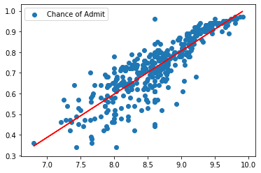

```python
def hypothesis(x, teta0, teta1):
    return teta0 + x*teta1

def MSE(x, y, teta0, teta1):
    divisor = len(x)*2
    sigmaArr = hypothesis(x, teta0, teta1) - y
    sigmaArrSqr = np.multiply(sigmaArr, sigmaArr)
    return np.sum(sigmaArrSqr) / divisor

x = attFrame['CGPA'].values
y = attFrame['Chance of Admit'].values
sigma1 = x - x.mean()
sigma2 = y - y.mean()

multDividend = np.multiply(sigma1, sigma2)
dividend = np.sum(multDividend)

multDivisor = np.multiply(sigma1, sigma1)
divisor = np.sum(multDivisor)

teta1 = dividend/divisor
teta0 = y.mean() - teta1*x.mean()

plt.plot(x, hypothesis(x, teta0, teta1), 'r')
plt.scatter(filledData["CGPA"], data["Chance of Admit"], label=col)
plt.legend()
print("MSE error : ", MSE(x, y, teta0, teta1))
```

### Part 3

The goal of this project was to determine the chance of admittance of a student by his/her statistics in different attributes. In the second part we determined that the CGPA attribute has the closest correlation to one and thus is the best attribute to calculate the chance of admittance by.  
In the last part, we calculated the hypothesis function parameters by the data frame we made in the part 1 of question 4.  
In this part, we calculate the chance of admittance of students with the hypothesis function.  
Overall output of this method is reasonable; As we see in the table below, students with higher chance of admittance have better overall TOEFL scores, better CGPA scores and etc. so their chances of acceptance should be higher than the others which is concluded via the table.

```python
pd.options.mode.chained_assignment = None
outputDf = filledData[filledData.isnull().any(axis=1)]
outputDf['Chance of Admit'] = hypothesis(outputDf['CGPA'].values, teta0, teta1)
outputDf
```

|  | Serial No. | GRE Score | TOEFL Score | University Rating | SOP | LOR | CGPA | Research | Chance of Admit |
| --- | --- | --- | --- | --- | --- | --- | --- | --- | --- |
| 1 | 2 | 324.000000 | 107.000000 | 4 | 4.0 | 4.5 | 8.87 | 1 | 0.779704 |
| 57 | 58 | 298.000000 | 99.000000 | 2 | 4.0 | 2.0 | 7.60 | 0 | 0.513433 |
| 135 | 136 | 314.000000 | 109.000000 | 4 | 3.5 | 4.0 | 8.77 | 1 | 0.758737 |
| 143 | 144 | 340.000000 | 120.000000 | 4 | 4.5 | 4.0 | 9.92 | 1 | 0.999849 |
| 171 | 172 | 316.759259 | 117.000000 | 5 | 4.0 | 4.5 | 9.07 | 1 | 0.821636 |
| 218 | 219 | 324.000000 | 110.000000 | 4 | 3.0 | 3.5 | 8.97 | 1 | 0.800670 |
| 232 | 233 | 312.000000 | 107.386842 | 2 | 2.5 | 3.5 | 8.27 | 0 | 0.653906 |
| 251 | 252 | 316.000000 | 99.000000 | 2 | 2.5 | 3.0 | 9.00 | 0 | 0.806960 |
| 272 | 273 | 294.000000 | 95.000000 | 1 | 1.5 | 1.5 | 7.64 | 0 | 0.521819 |
| 294 | 295 | 316.759259 | 101.000000 | 2 | 2.5 | 2.0 | 8.32 | 1 | 0.664389 |
| 315 | 316 | 308.000000 | 104.000000 | 2 | 2.5 | 3.0 | 8.07 | 0 | 0.611974 |
| 338 | 339 | 323.000000 | 108.000000 | 5 | 4.0 | 4.0 | 8.74 | 1 | 0.752447 |
| 357 | 358 | 301.000000 | 104.000000 | 2 | 3.5 | 3.5 | 7.89 | 1 | 0.574235 |
| 381 | 382 | 319.000000 | 105.000000 | 3 | 3.0 | 3.5 | 8.67 | 1 | 0.737771 |
| 390 | 391 | 314.000000 | 102.000000 | 2 | 2.0 | 2.5 | 8.24 | 0 | 0.647616 |
| 396 | 397 | 325.000000 | 107.000000 | 3 | 3.0 | 3.5 | 9.11 | 1 | 0.830023 |